# Qualitative prediction to the Weight Lifting Exercises Dataset

Practical Machine Learning Project

Mohammed Derouich

May 21th, 2015

## Introduction

Using devices such as Jawbone Up, Nike FuelBand, and Fitbit it is now possible to collect a large amount of data about personal activity relatively inexpensively. These type of devices are part of the quantified self movement - a group of enthusiasts who take measurements about themselves regularly to improve their health, to find patterns in their behavior, or because they are tech geeks. One thing that people regularly do is quantify how much of a particular activity they do, but they rarely quantify how well they do it. In this project, your goal will be to use data from accelerometers on the belt, forearm, arm, and dumbell of 6 participants. They were asked to perform barbell lifts correctly and incorrectly in 5 different ways. More information is available from the website [here](http://groupware.les.inf.puc-rio.br/har) (see the section on the Weight Lifting Exercise Dataset).

## Getting and exploration Data

The Weight Lifting Exercises (WLE) dataset is used to investigate how well an activity is being performed. Six participants were performing one set of 10 repetitions of the Unilateral Dumbbell Biceps Curl in five different fashions:

Class A - exactly according to the specification

Class B - throwing the elbows to the front

Class C - lifting the dumbbell only halfway

Class D - lowering the dumbbell only halfway

Class E - throwing the hips to the front.

Class A corresponds to the specified execution of the exercise, while the other 4 classes correspond to common mistakes.

We get the Data from these links:

- https://d396qusza40orc.cloudfront.net/predmachlearn/pml-training.csv for training data
- https://d396qusza40orc.cloudfront.net/predmachlearn/pml-testing.csv for testing data

```r
training <- read.table("./pml-training.csv", sep=","
                       , header=TRUE)
testing <- read.table("./pml-testing.csv", sep=",",
                      header=TRUE)
```

```r
dim(training)
```

```
## [1] 19622   160
```

```r
dim(testing)
```

```
## [1]  20 160
```

```r
str(training$classe)
```

```
##  Factor w/ 5 levels "A","B","C","D",..: 1 1 1 1 1 1 1 1 1 1 ...
```

```r
summary(training$classe)
```

```
##    A    B    C    D    E
## 5580 3797 3422 3216 3607
```

The training dataset comes with 19622 observations of 160 variables. The outcome is the variable “classe”. regarding to the definition of the barlift fashion we will focuse on raw variables that describe the movement in all directions. For this we will use the x, y, and z values + euler angles (roll, pitch and yaw) + accelerometer and gyroscope, and magnetometer.

We estimate that with this group of variables we could identify the “classe” of every exercise.

```r
predictorId <- c(grep("^accel", names(training)),
                  grep("^gyros", names(training)),
                  grep("^magnet", names(training)),
                  grep("^roll", names(training)),
                  grep("^pitch", names(training)),
                  grep("^yaw", names(training)),
                  grep("^total", names(training)))
trainPredSet <- training[, c(predictorId, 160)]
testPredSet <- testing[, c(predictorId, 160)]
length(predictorId)
```

```
## [1] 52
```

The included predictors in the prediction model are listed below. None of them shows a zero or near zero variance which would help to identify candidates for further reducing the set of predictors.

```r
library(caret)
nearZeroVar(trainPredSet[, -53], saveMetric = TRUE)
```

```
##                      freqRatio percentUnique zeroVar   nzv
## accel_belt_x          1.055412     0.8357966   FALSE FALSE
## accel_belt_y          1.113725     0.7287738   FALSE FALSE
## accel_belt_z          1.078767     1.5237998   FALSE FALSE
## accel_arm_x           1.017341     3.9598410   FALSE FALSE
## accel_arm_y           1.140187     2.7367241   FALSE FALSE
## accel_arm_z           1.128000     4.0362858   FALSE FALSE
## accel_dumbbell_x      1.018018     2.1659362   FALSE FALSE
## accel_dumbbell_y      1.053061     2.3748853   FALSE FALSE
## accel_dumbbell_z      1.133333     2.0894914   FALSE FALSE
## accel_forearm_x       1.126437     4.0464784   FALSE FALSE
## accel_forearm_y       1.059406     5.1116094   FALSE FALSE
## accel_forearm_z       1.006250     2.9558659   FALSE FALSE
## gyros_belt_x          1.058651     0.7134849   FALSE FALSE
## gyros_belt_y          1.144000     0.3516461   FALSE FALSE
## gyros_belt_z          1.066214     0.8612782   FALSE FALSE
## gyros_arm_x           1.015504     3.2769341   FALSE FALSE
## gyros_arm_y           1.454369     1.9162165   FALSE FALSE
## gyros_arm_z           1.110687     1.2638875   FALSE FALSE
## gyros_dumbbell_x      1.003268     1.2282132   FALSE FALSE
## gyros_dumbbell_y      1.264957     1.4167771   FALSE FALSE
## gyros_dumbbell_z      1.060100     1.0498420   FALSE FALSE
## gyros_forearm_x       1.059273     1.5187035   FALSE FALSE
## gyros_forearm_y       1.036554     3.7763735   FALSE FALSE
## gyros_forearm_z       1.122917     1.5645704   FALSE FALSE
## magnet_belt_x         1.090141     1.6664968   FALSE FALSE
## magnet_belt_y         1.099688     1.5187035   FALSE FALSE
## magnet_belt_z         1.006369     2.3290184   FALSE FALSE
## magnet_arm_x          1.000000     6.8239731   FALSE FALSE
## magnet_arm_y          1.056818     4.4439914   FALSE FALSE
## magnet_arm_z          1.036364     6.4468454   FALSE FALSE
## magnet_dumbbell_x     1.098266     5.7486495   FALSE FALSE
## magnet_dumbbell_y     1.197740     4.3012945   FALSE FALSE
## magnet_dumbbell_z     1.020833     3.4451126   FALSE FALSE
## magnet_forearm_x      1.012346     7.7667924   FALSE FALSE
## magnet_forearm_y      1.246914     9.5403119   FALSE FALSE
## magnet_forearm_z      1.000000     8.5771073   FALSE FALSE
## roll_belt             1.101904     6.7781062   FALSE FALSE
## roll_arm             52.338462    13.5256345   FALSE FALSE
## roll_dumbbell         1.022388    84.2065029   FALSE FALSE
## roll_forearm         11.589286    11.0895933   FALSE FALSE
## pitch_belt            1.036082     9.3772296   FALSE FALSE
## pitch_arm            87.256410    15.7323412   FALSE FALSE
## pitch_dumbbell        2.277372    81.7449801   FALSE FALSE
## pitch_forearm        65.983051    14.8557741   FALSE FALSE
## yaw_belt              1.058480     9.9734991   FALSE FALSE
## yaw_arm              33.029126    14.6570176   FALSE FALSE
## yaw_dumbbell          1.132231    83.4828254   FALSE FALSE
## yaw_forearm          15.322835    10.1467740   FALSE FALSE
## total_accel_belt      1.063160     0.1477933   FALSE FALSE
## total_accel_arm       1.024526     0.3363572   FALSE FALSE
## total_accel_dumbbell  1.072634     0.2191418   FALSE FALSE
## total_accel_forearm   1.128928     0.3567424   FALSE FALSE
```

We do some plots, for example about roll axis, but these dont show any direct correlation between “classe” and variables taken separately. That makes us think that the combination of a number of variables could identify the “classe”. That is why we will use the random forest model.

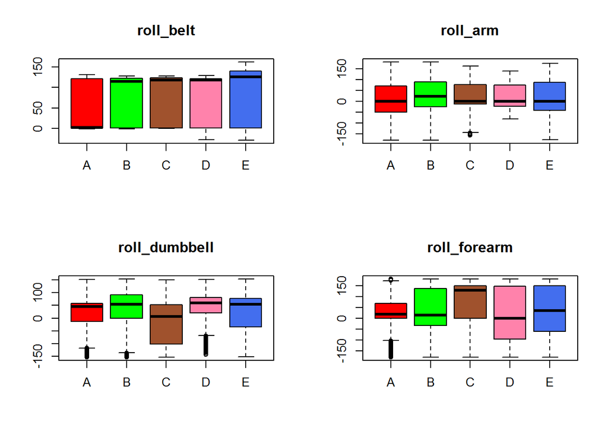

```r
par(mfrow = c(2,2))
boxplot(trainPredSet[, "roll_belt"] ~ trainPredSet$classe,
    col = c("red","green","sienna","palevioletred1","royalblue2"),
    main = "roll_belt")
boxplot(trainPredSet[, "roll_arm"] ~ trainPredSet$classe,
    col = c("red","green","sienna","palevioletred1","royalblue2"),
    main = "roll_arm")
boxplot(trainPredSet[, "roll_dumbbell"] ~ trainPredSet$classe,
    col = c("red","green","sienna","palevioletred1","royalblue2"),
    main = "roll_dumbbell")
boxplot(trainPredSet[, "roll_forearm"] ~ trainPredSet$classe,
    col = c("red","green","sienna","palevioletred1","royalblue2"),
    main = "roll_forearm")
```

## Model Training and Cross-Validation

The dataset is splitted into training and validation set using 75%-25% of the original dataset, respectively. The training set is the one that is used during model training.

```r
set.seed(13221)
inTrain <- createDataPartition(trainPredSet$classe, p = 0.75, list = FALSE)
train <- trainPredSet[inTrain, ]
validation <- trainPredSet[-inTrain, ]
```

```r
library(randomForest)
model.RF <- randomForest(classe ~ .,
                         data = train,
                         ntree = 20)
```

Then, we perform cross-validation to determine the appropriate number of variables to consider for model training.

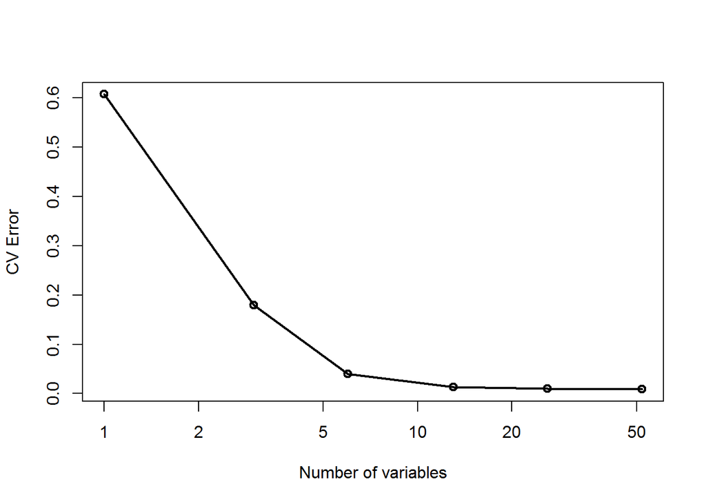

```r
result <- rfcv(trainx = train[ , -53], trainy = train[ , 53], ntree = 20)
with(result, plot(n.var,
                  error.cv,
                  log = "x",
                  type = "o",
                  lwd = 2,
                  xlab = "Number of variables",
                  ylab = "CV Error"))
```

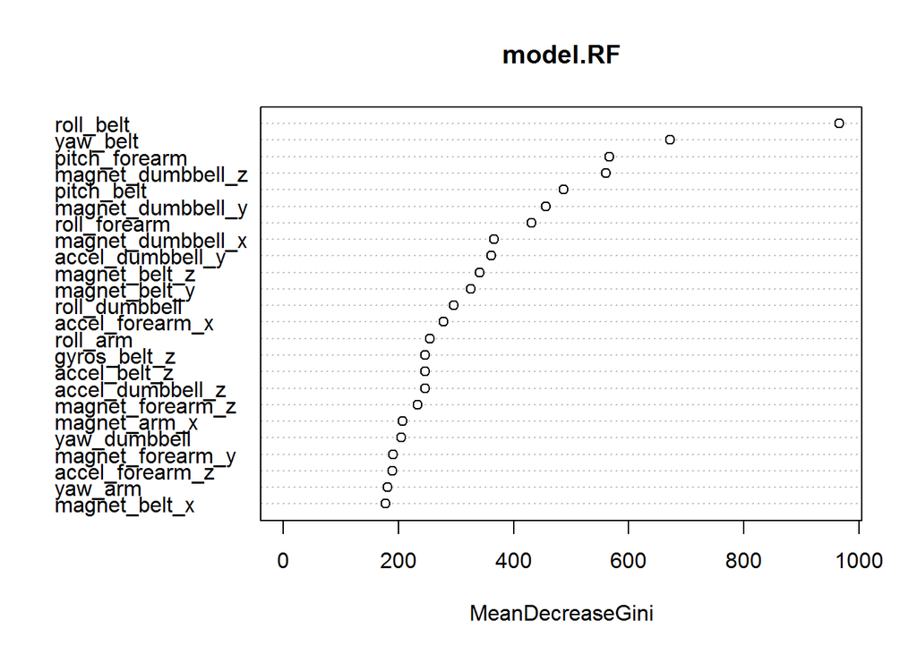

```r
varImpPlot(model.RF, n.var = 24)
```

We re-train our model using these top variables.

```r
variables <- varImp(model.RF)
top.names <- rownames(variables)[order(variables, decreasing = TRUE)][1:24]

model.RF.top <- randomForest(x = train[ , top.names],
                             y = train$classe,
                             ntree = 20)
```

Once the model is trained, we check its performance using the validation set.

```r
pred <- predict(model.RF.top, validation)
confusionMatrix(pred, validation$classe)
```

```
## Confusion Matrix and Statistics
##
##           Reference
## Prediction    A    B    C    D    E
##          A 1395   10    0    0    0
##          B    0  934    9    0    0
##          C    0    5  846    7    3
##          D    0    0    0  797    5
##          E    0    0    0    0  893
##
## Overall Statistics
##
##                Accuracy : 0.992
##                  95% CI : (0.9891, 0.9943)
##     No Information Rate : 0.2845
##     P-Value [Acc > NIR] : < 2.2e-16
##
##                   Kappa : 0.9899
##  Mcnemar's Test P-Value : NA
##
## Statistics by Class:
##
##                      Class: A Class: B Class: C Class: D Class: E
## Sensitivity            1.0000   0.9842   0.9895   0.9913   0.9911
## Specificity            0.9972   0.9977   0.9963   0.9988   1.0000
## Pos Pred Value         0.9929   0.9905   0.9826   0.9938   1.0000
## Neg Pred Value         1.0000   0.9962   0.9978   0.9983   0.9980
## Prevalence             0.2845   0.1935   0.1743   0.1639   0.1837
## Detection Rate         0.2845   0.1905   0.1725   0.1625   0.1821
## Detection Prevalence   0.2865   0.1923   0.1756   0.1635   0.1821
## Balanced Accuracy      0.9986   0.9910   0.9929   0.9950   0.9956
```

The trained model has an accuracy of 99.2% with a 95% confidence interval of (98.91%, 99.43%) in the validation set. The out-of-sample error is of 0.8%.

## Prediction Results on Test Dataset

When using the described prediction model to predict the 20 different test cases from the original test dataset testing we obtain the following predictions:

```r
testPrediction <- predict(model.RF.top, newdata = testPredSet)
print(rbind(testing[1:20, 160], as.character(testPrediction)))
```

```
##      [,1] [,2] [,3] [,4] [,5] [,6] [,7] [,8] [,9] [,10] [,11] [,12] [,13]
## [1,] "1"  "2"  "3"  "4"  "5"  "6"  "7"  "8"  "9"  "10"  "11"  "12"  "13"
## [2,] "B"  "A"  "B"  "A"  "A"  "E"  "D"  "B"  "A"  "A"   "B"   "C"   "B"
##      [,14] [,15] [,16] [,17] [,18] [,19] [,20]
## [1,] "14"  "15"  "16"  "17"  "18"  "19"  "20"
## [2,] "A"   "E"   "E"   "A"   "B"   "B"   "B"
```

## Summary

After submission the 20-results on Coursera.org, we obtain 20/20 correct response ! We have, here, 100% success due to small number of test 20 and higher accuracy 99.2 % of our model. That means we won’t obtain 100% every time, especially when the number of test increases. However we still stay around the 99.2%, which is a very good score.